# EDAV Final Project NYC Tree Census

Ruizhi Zhang, Jie Zheng, Junnan Zhao, Yawen Han

December 8, 2018

# 1. INTRODUCTION

With the development of modern industry, the urban population has increased dramatically, the environment has deteriorated, and the ecology has been seriously threatened. Urban greening can improve the quality of life by purifying the air, reducing noise, and beautifying the environment. As one of the most crucial cities in the United States, New York City (NYC)’s greening does not reflect the overall greening level of American cities, but also set a good example for other cities in the world. Therefore, our project is mainly to study the greening level in NYC. As the tree planting level is an important indicator of urban greening among many greening indicators, our research project narrows down to the study of the tree planting level in NYC, in order to give a good picture of the greening level in NYC to the readers.

Our data comes from New York Open Data resource which provides 2015 street trees information in NYC. Based on the data availability, our project aims to explore the following questions: 1) How is the survival situation and health condition of NYC street trees? 2) What factors impact the tree’s living situation significantly? 3) Whether these relationships and conclusions vary across different boroughs in NYC?

In our analysis, we first examine the reliability of the data set, including the amount of missing values and data’s biases, and then clean up data based on the analysis results. With a cleaned dataset, we analyzed the distribution of trees’ status, whether the tree is alive, standing dead, or a stump. The health conditions of survived trees, as well as diameters of the trees are investigated accordingly. With one step further, we dig in the data to see whether these properties and attribute are related to variables such as tree guards, steward, boroughs, etc.. Finally, we discuss the limitations and future work.

Each team member evolved in all parts and contributes equally to this project. All members participated in main analysis part. Jie Zheng and Yawen Han took charge of interactive component, Ruizhi Zhang mainly focused on Data Analysis Quality part, Junnan Zhao was in charge of Data Description. In the end, we finished report together, including introduction and conclusions.

# 2. DESCRIPTION OF DATA

Table 1: Description of Raw NYC Street Tree Variables

https://github.com/RuizhiZhang/EDAVfinalprojectNYCtrees/blob/master/Table%201.pdf

# 3. ANALYSIS OF DATA QUALITY

## 3.1 Missing Patterns

Firstly, the dataset is loaded here, and a subset as mentioned in data description part is extracted into **Tree** variable.

```r
library(tidyverse)
library(ggthemes)
library(dplyr)

# loading data
Tree<-read.csv("Tree_Data.csv")

# create a subset for tree dataset w/ demanded attributes
Tree<-Tree[,c('tree_dbh','stump_diam','curb_loc','status','health','spc_common','steward',
              'guards','user_type','postcode','borough')]
```

## 3.2 Missing Value Bar Chart

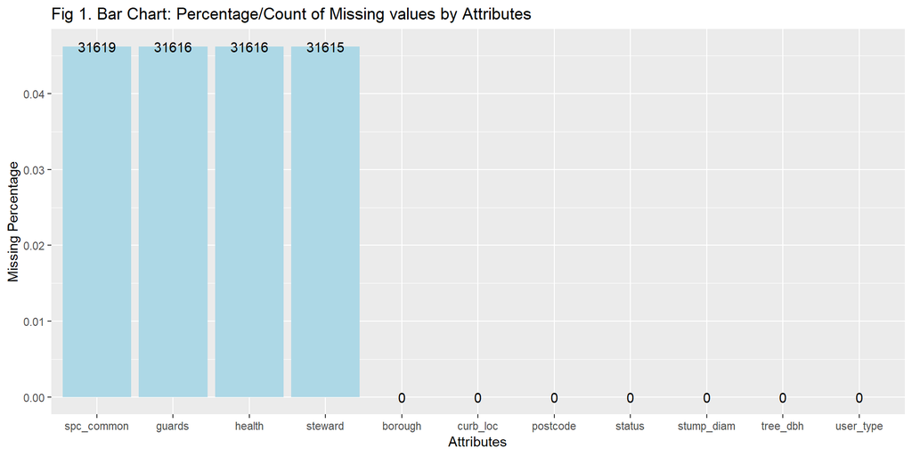

```r
# standardization
Tree[Tree == '']<-NA

TreeMiss<-colSums(is.na(Tree))
TreeMissPercent<-TreeMiss/length(Tree$tree_dbh)
TreeValue<-names(TreeMissPercent)
TreePercent<-unname(TreeMissPercent)
TreeMissPer<-data.frame(TreeValue,TreePercent)
ggplot(TreeMissPer, aes(x=reorder(TreeValue,-TreePercent),
                        y=TreePercent))+geom_bar(
                          stat="identity",fill="lightblue")+geom_text(
                            aes(label=TreeMiss))+ggtitle(
  "Fig 1. Bar Chart: Percentage/Count of Missing values by Attributes")+labs(x="Attributes",
y="Missing Percentage")
```

According to the bar chart of the missing value, the missing values were distributing in spc_common, guards, health, and steward with value around 31620 for each, occupying more than 4.5% of the total observations. Then, the specific missing pattern was shown below.

## 3.3 Missing Value Heatmap

```r
library(extracat)
cat("Fig 2. Heatmap: Missing Value")
```

```
## Fig 2. Heatmap: Missing Value
```

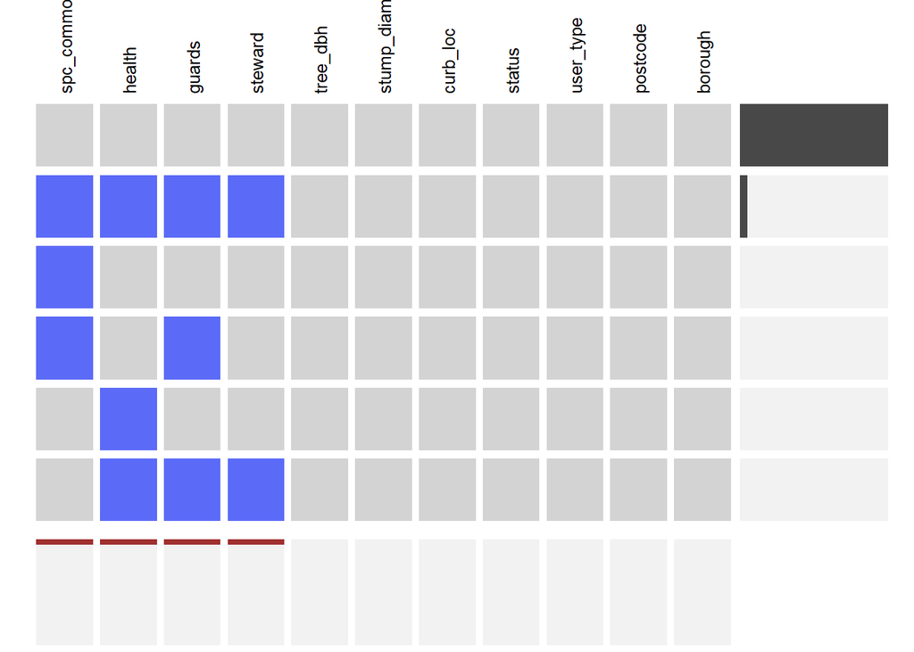

```r
visna(Tree,sort="b")
```

According to the missing value heatmap, there were in total 5 missing patterns:

1. All four spc_common, guards, health, and steward are missing, which was the largest portion of missing except no missing obs.;
2. Only spc_common missing;
3. spc_common and guards missing;
4. Only health missing;
5. health, guards, and steward missing;

Compared to the full-set observations, the number of missing for each pattern was too tiny to observable.

There were some reasons resulting in the distribution of missing values. One important reason was the varibales in status. For both stump and dead tree, it was resonable that it was hard for the recorders to provided info for those trees.

```r
cat("Table 2. Correlation of Missing Value against Status")
```

```
## Table 2. Correlation of Missing Value against Status
```

```r
Tree %>%
  group_by(status) %>%
  summarize(tree_spc_num_na = sum(is.na(`spc_common`))/n(),
            tree_health_num_na = sum(is.na(`health`))/n(),
            tree_guards_num_na = sum(is.na(`guards`))/n(),
            tree_steward_num_na = sum(is.na(`steward`))/n())
```

| status | tree_spc_num_na | tree_health_num_na | tree_guards_num_na | tree_steward_num_na |
| --- | --- | --- | --- | --- |
| Alive | 7.666677e-06 | 1.533335e-06 | 1.533335e-06 | 0 |
| Dead | 9.999284e-01 | 1.000000e+00 | 1.000000e+00 | 1 |
| Stump | 1.000000e+00 | 1.000000e+00 | 1.000000e+00 | 1 |

Then, a brief analysis of stump and dead trees was shown here. Firstly, the sum of the all stump and dead trees was calculated as below.

```r
# #of both Stump and Dead trees
sum(Tree$status == "Stump") + sum(Tree$status == "Dead")
```

```
## [1] 31615
```

```r
# percentage of total observations
cat('The percentage of the stump and dead trees is around',
    round(31615/length(Tree$status)*100), '% of the total recorded trees.')
```

```
## The percentage of the stump and dead trees is around 5 % of the total recorded trees.
```

## 3.4 Detailed Statistic Features

```r
dim(Tree)
```

```
## [1] 683788     11
```

```r
names(Tree)
```

```
##  [1] "tree_dbh"   "stump_diam" "curb_loc"   "status"     "health"
##  [6] "spc_common" "steward"    "guards"     "user_type"  "postcode"
## [11] "borough"
```

Categorical: curb_loc, status, health, spc_common, steward, guards, user_type, postcode, borough

Discrete: tree_dbh, stump_diam

## 3.5 Discrete Variable Outliers

Since there was only two features, tree_dbh and stump_diam, being discrete variables. Firstly, as a first shot of the outliers of tree dbh, a boxplot was plotted.

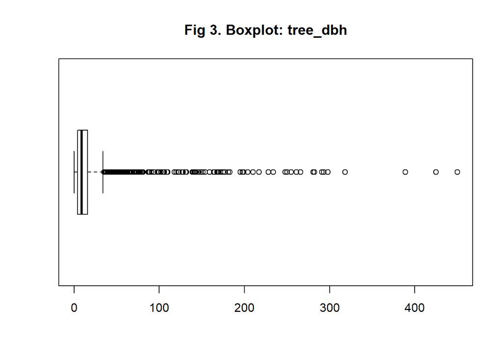

```r
boxplot(Tree$tree_dbh, horizontal = TRUE, main="Fig 3. Boxplot: tree_dbh")
```

According to the boxplot shown above, the dbh were heavely spreaded from 0 to more than 400, where the main distribution was concentrated within 30. By zooming in, a 5-value summary was calculated as below: 5-value summary:

```r
boxplot.stats(Tree$tree_dbh)[1]
```

```
## $stats
## [1]  0  4  9 16 34
```

For all dbh of trees, the min value was 0, the lower hinge was 4, the median was 9, the upper hinge was 16, and the max value was 34. However, according to the data description, the dbh of stumps were set to 0, redo the statistics for non-stump trees.

```r
boxplot.stats(Tree$tree_dbh[Tree$status != "Stump"])[1]
```

```
## $stats
## [1]  0  5 10 16 32
```

Therefore, the dbh larger than 16+(16-5)*1.5=32.5 were outliers.

```r
# # of outliers
sum(Tree$tree_dbh>32.5)
```

```
## [1] 15405
```

```r
# percentage of outliers
sum(Tree$tree_dbh>32.5)/length(Tree$tree_dbh)
```

```
## [1] 0.02252891
```

On the other hand, there were some concerns about the stump and non-stump diameters.

```r
mean(Tree$stump_diam[Tree$status == "Stump"])
```

```
## [1] 16.75048
```

```r
mean(Tree$tree_dbh[Tree$status != "Stump"])
```

```
## [1] 11.57873
```

The mean of the stump was fairly larger than the mean of the non-stump trees. There might be two hypothesis could be considered. The reason why the stumps were lefted rather than removed from roots might result from the concerning of diameters of the trees. The thicker the stumps were, the harder the trees could be totally removed. Moreover, the stumped trees might be cut because they were too thick that they became the obstacles in human living senarios.

## 3.6 Data Biases Check

We may consider if the “user_type” (who count the trees) will influence the count result? In comnnon sense, the “Tree count staff” and “NYC Parks staff” are more professional and provide more reliable count results, while the “Volunteer” may provide a higher error rate result.

Plot the grouped bar plot to explore the distribution of street trees of each user_type based on borough. “User_type” describes the category of user who collected this tree point’s data. The order of bough in each group is based on the descending order of total count numbers obtatined in the above section.

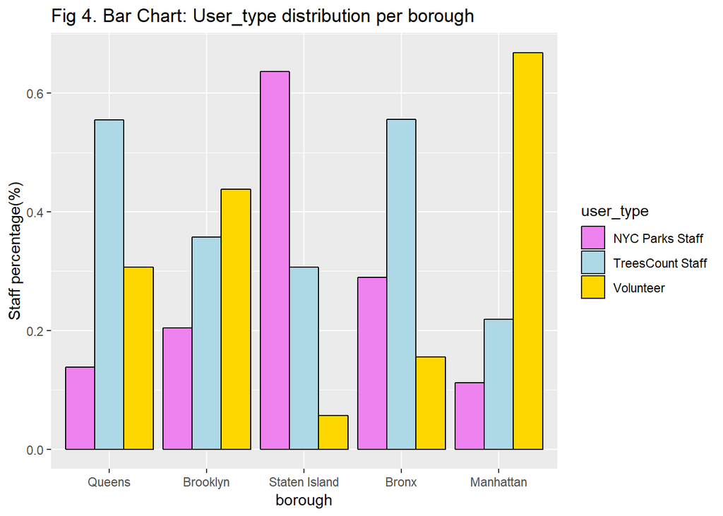

```r
Tree$borough<-factor(Tree$borough,levels=c("Queens", "Brooklyn",
                                           "Staten Island", "Bronx","Manhattan"))
ggplot(Tree, aes(x = borough,fill=user_type)) +
   geom_bar(aes( y=..count../tapply(..count.., ..x.. ,sum)[..x..]),
            position="dodge" ,color="black") +
  scale_fill_manual(values = c("violet","lightblue","gold"))+ylab(
    "Staff percentage(%)") + ggtitle(
      "Fig 4. Bar Chart: User_type distribution per borough")
```

From the grouped bar plot above, the distribution of stree trees of different user_type based on borough are compared as follows:

1)The user_type has different staff percentage reatio for five borough, which implies that the user_type ratio might have a relationship with the final TreeCount results;

2)“Queens”, the borough with most street trees counts, has its biggest user_type as “TreesCount Staff”;

According to the observations above, the user_type did show somewhat relationship with the final TreeCount result. To investigate the possible relationship between two categorical variables, “user_type” and “TreeCount”, the mosaic plot was generated below:

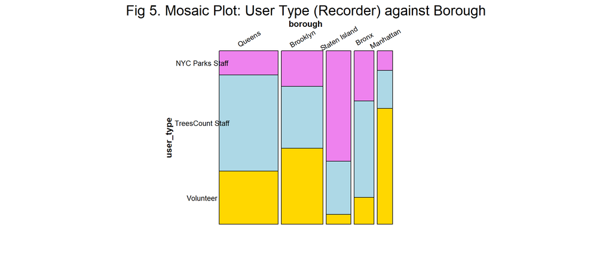

```r
library(vcd)
library(grid) # needed for gpar
fillcolors <- c("violet","lightblue","gold")
Tree$borough<-factor(Tree$borough,levels=c("Queens", "Brooklyn", "Staten Island",
                                           "Bronx","Manhattan"))
vcd::mosaic( user_type ~ borough, Tree, gp = gpar(fill = fillcolors),
             main="Fig 5. Mosaic Plot: User Type (Recorder) against Borough",
             direction = c("v", "h"),tl_labels = c(TRUE, TRUE),
             labeling = labeling_border(gp_labels = gpar(fontsize = 10),
                                        gp_varnames = gpar(fontsize = 12,fontface = 2),
                                        rot_labels = c(30,0, 0, 0),
                                        rot_varnames = c(0,0,0,90),
                                        offset_varnames = c(0.7,0,0,3.0),
                                        offset_labels=c(0.5,0,0,1),
                                        pos_labels = c("center", "center",
                                                       "left", "center")))
```

Therefore, we can conclued that

1)User_type, the category of user who collected this tree point’s data, had different percentage ratio for each borough;

2)Different user_type ratio had influence on the final TreeCount result, as “NYC Parks Staff” and “TreesCount Staff” with more professional knowledge would provide a more reliable data, while “Volunteer” with less experience would provide more mistakes.

Above all, different user_type had different recording criteria, and the five boroughs did not have the identical user_type percentage ratio, which implies that occurance of bias in the given NYC Census dataset.

# 4. MAIN ANALYSIS

## 4.1 Data Cleaning Process

After subsetting data, as mentioned in data quality part, the info for those stumped and dead trees were despretely lost where we already set them as NA. The percentage of these trees were about 5%, which was tolarable for our analysis. Therefore, these portions of data was removed as demanded for some parts use. This value will be applied to the next few parts.

```r
TreeNonNA <- subset(Tree, !(Tree$status %in% "Stump") & !(Tree$status %in% "Dead"))
```

Specifically for tree diameters, the outliers could be removed due to the low proportion and trivial concerns. This value will be applied to the next few parts.

```r
TreeNoOut <- subset(Tree, Tree$tree_dbh <= 32.5)
```

## 4.2 Tree Properties Data Analysis

### 4.2.1 Tree Diameters

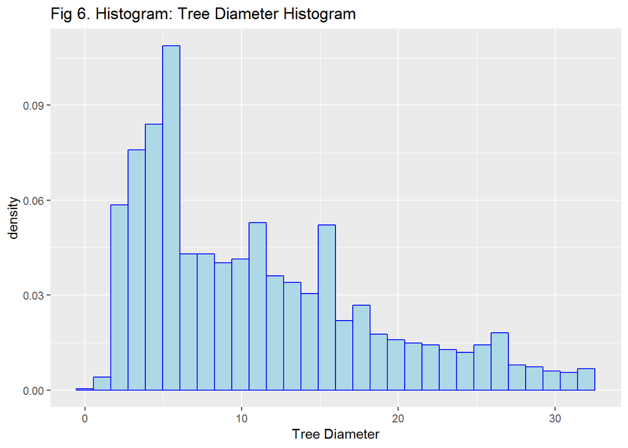

```r
ggplot(subset(TreeNoOut,!(status %in% "Stump")))+geom_histogram(
  aes(x=tree_dbh,y=..density..),
  fill="lightblue",color="blue")+xlab("Tree Diameter")+labs(
    title="Fig 6. Histogram: Tree Diameter Histogram")
```

According to the histogram, we could see that the most diameters fall in small sizes. The largest count value is 5-6, about 10%. The distribution appears to be positive skewed.

### 4.2.2 Status

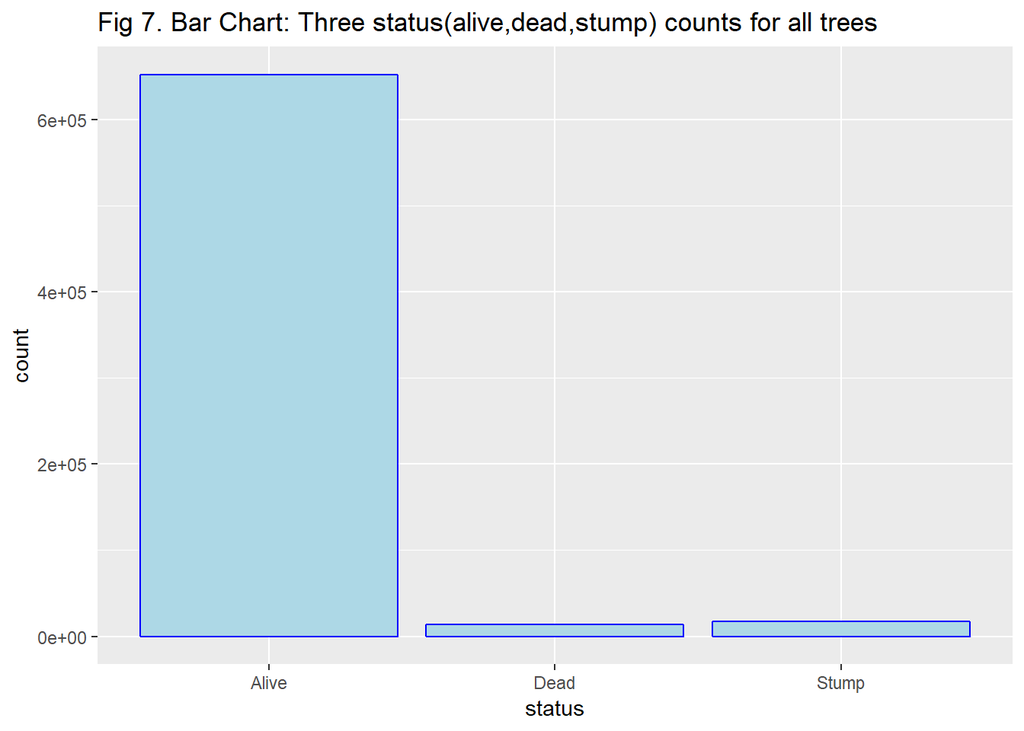

```r
ggplot(Tree, aes(status)) +
geom_histogram(stat='count',fill="lightblue",color="blue") +
ggtitle("Fig 7. Bar Chart: Three status(alive,dead,stump) counts for all trees")
```

We can see the count number of alive trees is much higher than dead trees and trees with stump conditions. What is more, the count number of dead tree is roughly equals to trees with stump condition.

### 4.2.3 Health

```r
Tree$health <- factor(Tree$health, ordered = TRUE, levels <- c("Poor", "Fair", "Good"))
summary(Tree$health)
```

```
##   Poor   Fair   Good   NA's
##  26818  96504 528850  31616
```

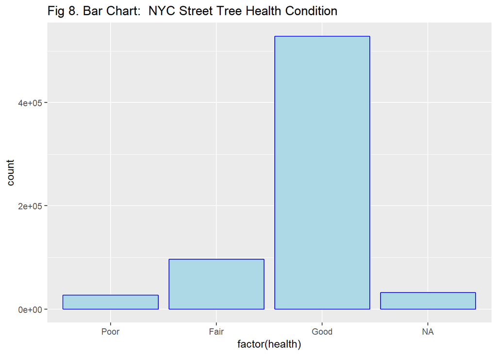

```r
g_health <- ggplot(Tree, aes(x = factor(health)), width=0.5) +
              geom_bar(fill="lightblue",color="blue") +
              ggtitle("Fig 8. Bar Chart:  NYC Street Tree Health Condition") +
              theme_get()
g_health
```

As figure 8 shows, the trees in good condition is about 81.1% of all the alive trees, fair condition trees is about 14.8% and poor condition is about 4.1%. The trees without any health condition data are dead (NAs). The dead and poor condition trees are about the same amount.

### 4.2.4 Species

```r
summary(Tree$spc_common)
```

```
##       London planetree            honeylocust           Callery pear
##                  87014                  64264                  58931
##                pin oak           Norway maple      littleleaf linden
##                  53185                  34189                  29742
##                 cherry       Japanese zelkova                 ginkgo
##                  29279                  29258                  21024
##                Sophora              red maple              green ash
##                  19338                  17246                  16251
##        American linden           silver maple               sweetgum
##                  13530                  12277                  10657
##       northern red oak          silver linden           American elm
##                   8400                   7995                   7975
##                  maple       purple-leaf plum        swamp white oak
##                   7080                   6879                   6598
##     crimson king maple            Chinese elm 'Schubert' chokecherry
##                   5923                   5345                   4888
##    Japanese tree lilac         eastern redbud        golden raintree
##                   4568                   3801                   3719
##             crab apple    Kentucky coffeetree             willow oak
##                   3527                   3364                   3184
##           dawn redwood               hawthorn            sugar maple
##                   3020                   2988                   2844
##         sycamore maple                    ash            hedge maple
##                   2731                   2609                   2550
##       common hackberry           sawtooth oak           Amur maackia
##                   2382                   2244                   2197
##      European hornbeam             Amur maple           serviceberry
##                   2099                   2049                   2032
##           black locust              white oak            English oak
##                   1784                   1686                   1644
##           Siberian elm      flowering dogwood      American hornbeam
##                   1595                   1552                   1517
##         Schumard's oak            scarlet oak              black oak
##                   1487                   1465                   1327
##           bald cypress               mulberry         Japanese maple
##                   1261                   1157                   1130
##              white ash       eastern redcedar         horse chestnut
##                   1121                   1101                   1096
##   American hophornbeam           tulip-poplar       Cornelian cherry
##                   1081                   1076                   1066
```

[output cut: 13 more lines]

```
##                    328                    317                    302
##           silver birch           black walnut                   pine
##                    300                    295                    289
##               blackgum         weeping willow         pagoda dogwood
##                    288                    282                    280
##       Persian ironwood     eastern cottonwood         American beech
##                    277                    276                    273
##           empress tree     Chinese fringetree  two-winged silverbell
##                    245                    234                    221
##        paperbark maple        Oklahoma redbud                 spruce
##                    220                    219                    202
##             white pine         Amur cork tree                (Other)
##                    202                    183                   3259
##                   NA's
##                  31619
```

We find the number of species more than 100, and the range of species from highest count number to the lowest count number is 86,831.Therefore, we want to subset of the species which total number of counts with those species has large proportion on our total species count number. Then we select top 10 species without choosing species is blank(missing data with species).In the following analysis, for tree species varaible, we just focus on top ten tree species.

```r
Tree$species<-Tree$spc_common
for (i in levels(Tree$spc_common)){
  if ((i %in% c("London planetree", "honeylocust","Callery pear",
                "pin oak","Norway maple","littleleaf linden",
  "cherry","Japanese zelkova","ginkgo","Sophora"))==FALSE){
    Tree<-Tree %>%
      mutate(species = fct_recode(species,OTHER=i))
  }
}
trees<-subset(Tree, species != "OTHER")
trees$species<-factor(trees$species)
```

## 4.3 Tree Properties Dependencies

### 4.3.1 Health vs. Tree DBH

We draw the boxplot in terms of the health status. As a common sense, the larger the diameters are, the stronger the trees are. Therefore, the trees with good and fair status have the larger diameters.

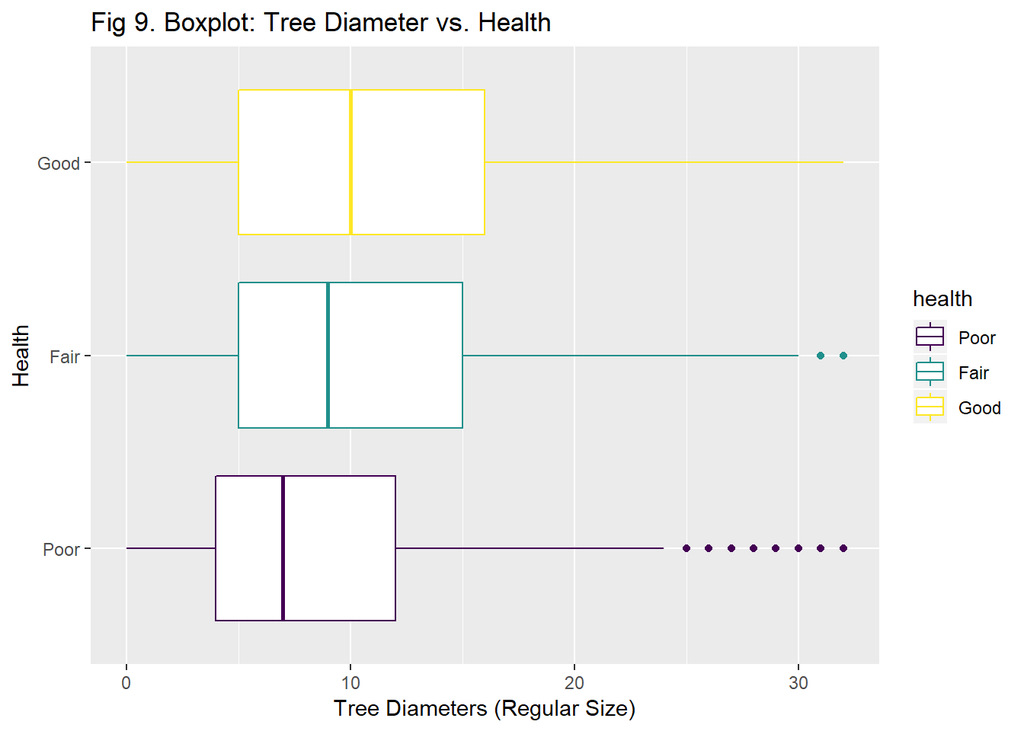

```r
healthbox<-ggplot(subset(Tree,tree_dbh <= 32.5 & !(health %in% NA) ))+geom_boxplot(
  aes(x=reorder(health,tree_dbh,FUN=median),
  y=tree_dbh,group=paste(health),
  color=health))+coord_flip() +   xlab("Health") +ylab(
    "Tree Diameters (Regular Size)")+labs(title="Fig 9. Boxplot: Tree Diameter vs. Health")
healthbox
```

### 4.3.2 Species vs. Tree DBH

```r
library(vcd)
library(dplyr)
group<-Tree %>%
      group_by(spc_common) %>%
      summarise(count=n())
group[order(-group$count),]
```

| spc_common | count |
| --- | --- |
| London planetree | 87014 |
| honeylocust | 64264 |
| Callery pear | 58931 |
| pin oak | 53185 |
| Norway maple | 34189 |
| NA | 31619 |
| littleleaf linden | 29742 |
| cherry | 29279 |
| Japanese zelkova | 29258 |
| ginkgo | 21024 |

[output cut: 123 more lines]

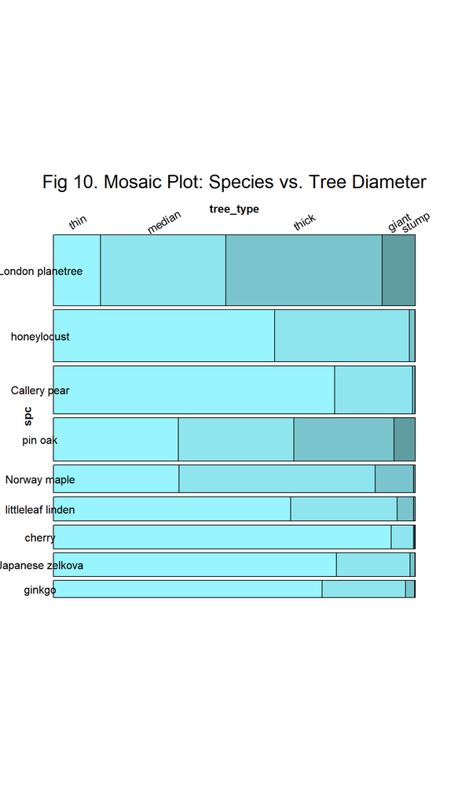

```r
Tree[['spc']]<-Tree$spc_common
for (i in levels(Tree$spc_common)){
  if ((i %in% c("London planetree", "honeylocust","Callery pear",
                "pin oak","Norway maple","littleleaf linden","cherry","Japanese zelkova","ginkgo"))==FALSE){
      Tree<-Tree %>%
          mutate(spc = fct_recode(spc,OTHER=i))
  }
}
Tree$tree_type <- Tree$tree_dbh
Tree$tree_type <- ifelse(Tree$tree_dbh<=11&Tree$tree_dbh>0,"thin",Tree$tree_type)
Tree$tree_type <- ifelse(Tree$tree_dbh>11&Tree$tree_dbh<22,"median",Tree$tree_type)
Tree$tree_type <- ifelse(Tree$tree_dbh>=22&Tree$tree_dbh<=32.5,"thick",Tree$tree_type)
Tree$tree_type <- ifelse(Tree$tree_dbh>32.5,"giant",Tree$tree_type)
Tree$tree_type <- ifelse(Tree$tree_dbh==0,"stump",Tree$tree_type)
# mosaic(tree_type ~ spc, Tree,rot_labels = c(30, 0, 0, 0))
Tree2<- Tree %>% filter(`spc` %in% c("London planetree",
                                     "honeylocust","Callery pear",
                                     "pin oak","Norway maple",
                                     "littleleaf linden","cherry",
                                     "Japanese zelkova","ginkgo"))
Tree2$spc <- factor(Tree2$spc,
                      levels = c("London planetree", "honeylocust",
                                 "Callery pear","pin oak","Norway maple",
                                 "littleleaf linden","cherry",
                                 "Japanese zelkova","ginkgo"))
Tree2$tree_type <- factor(Tree2$tree_type,
                      levels = c("thin", "median","thick","giant","stump"))
fillcolors=c("cadetblue1","cadetblue2","cadetblue3","cadetblue","cadetblue4")
mosaic(tree_type ~ spc, Tree2,rot_labels = c(30, 0, 0, 0),gp=gpar(fill=fillcolors),
       main="Fig 10. Mosaic Plot: Species vs. Tree Diameter")
```

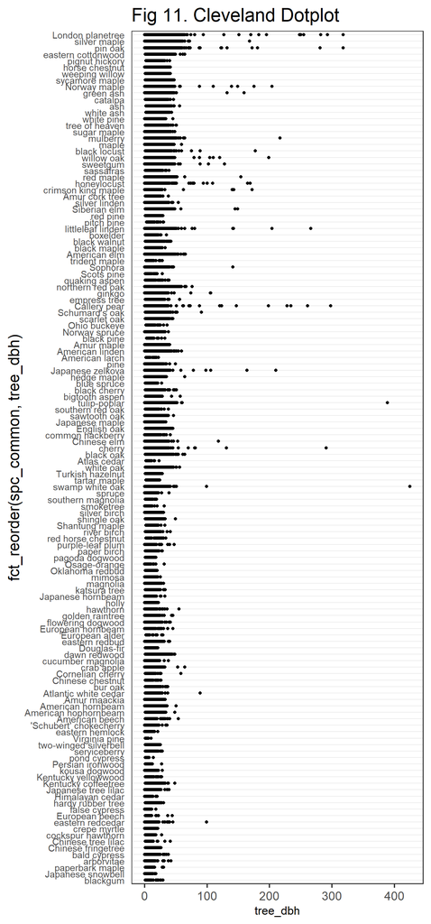

```r
theme_dotplot <- theme_bw(18) +
    theme(
          axis.text.y = element_text(size = rel(.75)),
          axis.ticks.y = element_blank(),
          axis.title.x = element_text(size = rel(.75)),
          panel.grid.major.x = element_blank(),
          panel.grid.major.y = element_line(size = 0.5),
          panel.grid.minor.x = element_blank())

ggplot(subset(Tree,!(spc_common %in% NA) & !(status %in% "Stump")))+geom_point(
  aes(x=tree_dbh,y=fct_reorder(
  spc_common,tree_dbh)))+theme_dotplot+ggtitle(
    "Fig 11. Cleveland Dotplot")
```

According to the dotplot shown above, the trees distributions for each species was relatively spreaded. For those species with large amount, there were very large spreading distributs, eg. London planetree, ranging from lowest to the highest values.

## 4.4 Data Attributes Dependencies

### 4.4.1 Tree Geographic Counts

First, to generate a overview of NYC street tree counts in each borough, the barchart was plotted with y-axis show the total count of street trees for each borough in NYC 2015 and the x-axis show the borough name. For better comparision of street tree counts in different borough, the plot was shown in decreasing order of total counts.

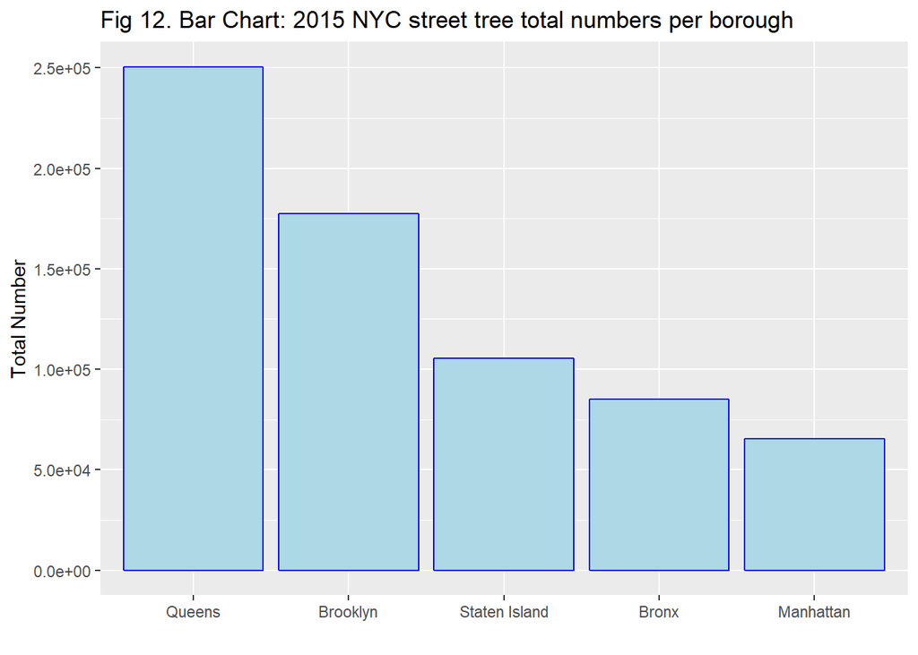

```r
library(scales)

Tree$borough<-factor(Tree$borough,levels=c("Queens", "Brooklyn",
                                           "Staten Island", "Bronx","Manhattan"))
b<-Tree %>% group_by(borough) %>% summarise(n=n())
# plot the barchart of total tree numbers by borough with a decreasing order
ggplot(b,aes(x=fct_reorder(borough,n,.desc=TRUE),y=n))+
  geom_bar(color="blue",fill="lightblue",stat="identity")+
  scale_y_continuous(labels = scientific)+
  ggtitle("Fig 12. Bar Chart: 2015 NYC street tree total numbers per borough")+labs(
    x="",y="Total Number")
```

According to the bar chart above, the total number order of NYC borough is ‘Queens’, ‘Brooklyn’, ‘Staten Island’, ‘Bronx’ and ‘Manhattan’. In year 2015, among all five boroughs, “Queens” had the largest number of street trees around 250,000, while “Manhattan” has the smallest number of street trees around 70,000, which is less than 1/3 of “Queens”. Thus, the barchart above demonstrated the distinct differeence of street trees counts between five boroughs.

In Figure 12 above, it demonstrated the distinct differeence of street trees counts between five boroughs. Thus, it’s interesting to furthur explore what cause the difference between the five boroughs, and the two most obvious are “Land Area” and “Population”. Consideirng the difference of “Land Area” and “Population” between five boroughs, we will try to recognize whether there exist relationships between these three variables: “borough”, “Land Area”, and “Population”.

The data of “borough”, “Land Area”, and “Population” is shown in the table below:

```r
borough_info <- data.frame("Borough" = c("Queens","Brroklyn",
                                         "Staten Island","Bronx",
                                         "Manhattan"), "LandArea(mi2)" =
                             c(109.7,71.5,58.5,42.4,22.8), "Population" = c(2230722,2504700,468730,1385108,1585873))
borough_info$LandArea.mi2.=as.numeric(borough_info$LandArea.mi2.)
borough_info$Population=as.numeric(borough_info$Population)
borough_info$TreeCount=b$n
borough_info
```

| Borough | LandArea.mi2. | Population | TreeCount |
| --- | --- | --- | --- |
| Queens | 109.7 | 2230722 | 250551 |
| Brroklyn | 71.5 | 2504700 | 177293 |
| Staten Island | 58.5 | 468730 | 105318 |
| Bronx | 42.4 | 1385108 | 85203 |
| Manhattan | 22.8 | 1585873 | 65423 |

To investigate the possible relationship between variables “TreeCount”, “Land Area”, and “Population” based on borough, two scatter plot “TreeCount vs LandArea” and “TreeCount vs Population” were generated below:

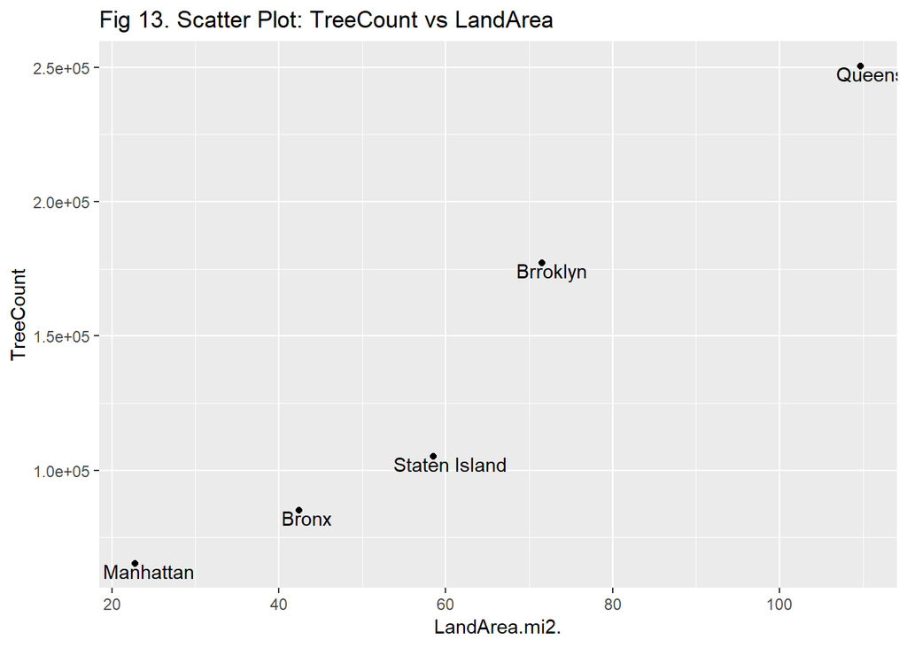

```r
ggplot(borough_info, aes(x=LandArea.mi2., y=TreeCount)) +scale_y_continuous(
  labels = scientific)+ geom_point()+geom_text(label=borough_info$Borough,vjust = 1,hjust=0.35)+ggtitle("Fig 13. Scatter Plot: TreeCount vs LandArea")
```

In Figure 13 above, the data points make a straight line going from the origin out to high x- and y-values, theerfore the two variables are said to have a positive correlation. It’s reasonable to concluded that the TreeCount difference between five boroughs are affected by the their LandArea.

Next, the scatterplot between “TreeCount” and “Population” based on borough:

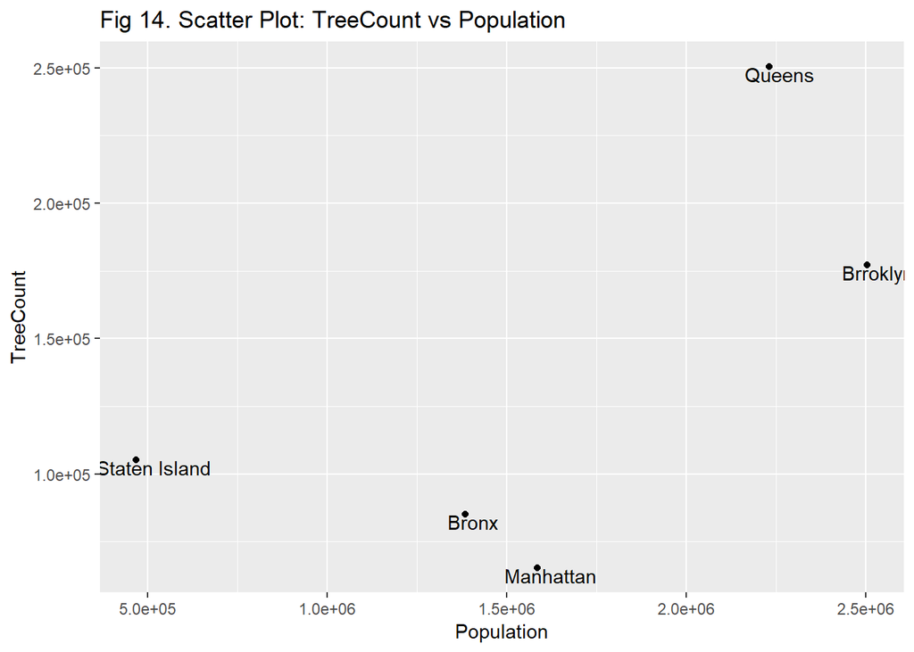

```r
ggplot(borough_info, aes(x=Population, y=TreeCount)) +scale_y_continuous(
  labels = scientific)+ geom_point()+geom_text(label=borough_info$Borough,vjust = 1,hjust=0.35)+scale_x_continuous(labels = scientific)+ggtitle(
    "Fig 14. Scatter Plot: TreeCount vs Population")
```

In the analysis above, we explore the TreeCount of NYC street trees based on borough, figuring out the difference of TreeCount in five boroughs, and the relationship between certain variables and borough. This provided a basic idea about the distribution of NYC street trees for five borough.

In this section, instead of using the borough as a border to demonstrate count data, “postcode” of each subarea was applied as boudaries in a choroplethic map.

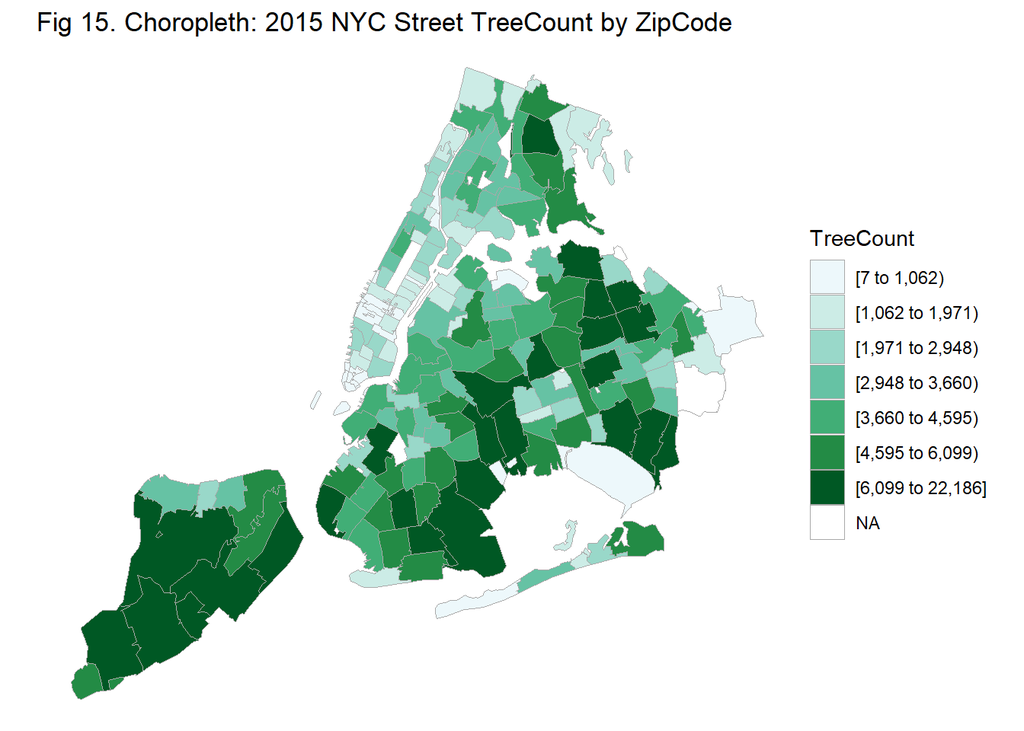

```r
library(devtools)
library(choroplethr)
library(choroplethrZip)
library(ggplot2)
data("zip.regions")
tree_summary<-Tree %>% group_by(postcode) %>% summarise(n=n())
tree_summary<-tree_summary[tree_summary$postcode %in% zip.regions$region,]
tree_summary<-rename(tree_summary,"region"="postcode","value"="n")
tree_summary$region<-as.character(tree_summary$region)
tree_summary$value<-as.numeric(tree_summary$value)
nyc_fips = c("36005", "36047", "36061", "36081", "36085")

choro = ZipChoropleth$new(tree_summary)
choro$title = "Fig 15. Choropleth: 2015 NYC Street TreeCount by ZipCode"
choro$ggplot_scale = scale_fill_brewer(name="TreeCount", palette=2, drop=FALSE)
choro$set_zoom_zip(state_zoom=NULL,county_zoom = nyc_fips, msa_zoom=NULL, zip_zoom=NULL)
choro$render()
```

The choropleth map above provided an easy way to visualize how the TreeCount varies across the subregion in NYC by the zipcode. To provide a better perceptual intuition, the map used “green” to represent the TreeCount numbers, and the darker the green color the higher the TreeCount data.

This choropleth map show the diistribution of street trees in in greater detail,and the visulization based on the map and color density provide a easier way to analysis the dataset.

### 4.4.2 Borough vs. Tree DBH

We draw the boxplot of the diameters faceted by the borough.

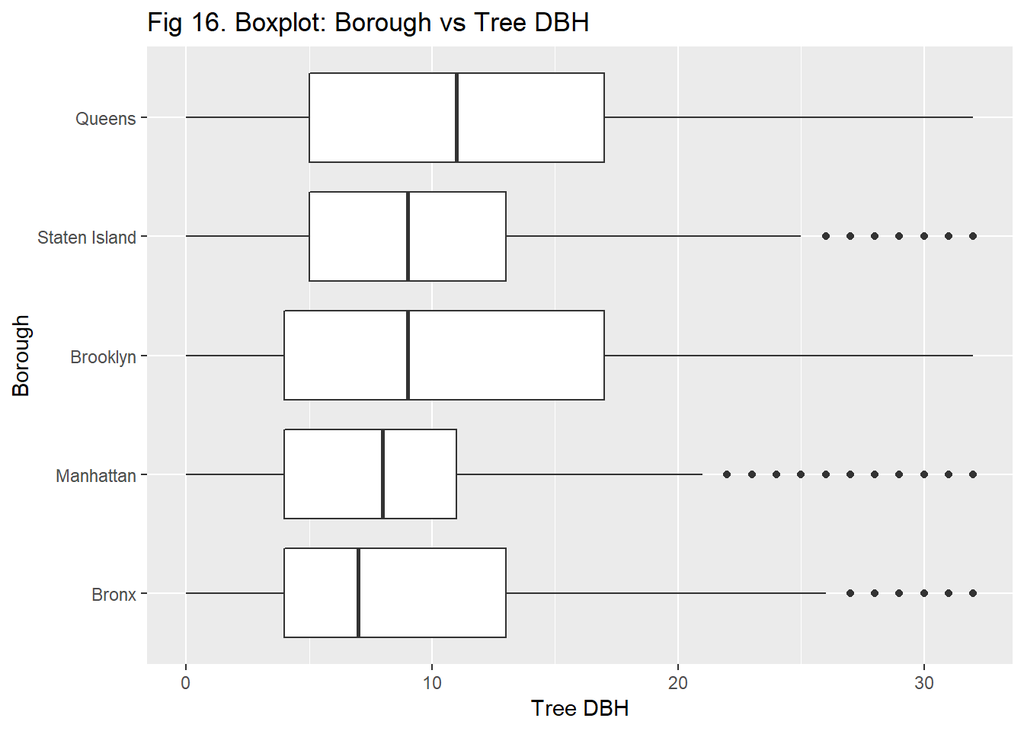

```r
BoroughDia <- ggplot(aes(x=reorder(borough,tree_dbh,FUN=median),
                         y=tree_dbh,group=paste(borough)),
                     data=TreeNoOut)+geom_boxplot()+coord_flip()+labs(
                       y= "Tree DBH", x = "Borough")
BoroughDia+ggtitle("Fig 16. Boxplot: Borough vs Tree DBH")
```

According to the boxplot, Queens has the largest median of diameters. Queens and Brooklyn have a wider range of the diameters.Bronx and Manhattan have smallest diameters maybe because the urbanlization of the boroughs.

Next, we categorized the regular sized (<=32.5) trees into three categories: thin, median, thick. The rest are stump and outliers (as giant). Being consistent with the results we got before, even Manhattan and Bronx have less trees, they own a large amount of the thinner trees b/c of the urbanlization.

```r
type<-Tree %>%
      group_by(tree_type) %>%
      summarise(count=n())
type[order(-type$count),]
```

| tree_type | count |
| --- | --- |
| thin | 396106 |
| median | 179279 |
| thick | 75066 |
| stump | 17932 |
| giant | 15405 |

```r
Tree$tree_type <- factor(Tree$tree_type,
                      levels = c("thin", "median","thick","giant","stump"))
borough<-Tree %>%
      group_by(borough) %>%
      summarise(count=n())
borough[order(-borough$count),]
```

| borough | count |
| --- | --- |
| Queens | 250551 |
| Brooklyn | 177293 |
| Staten Island | 105318 |
| Bronx | 85203 |
| Manhattan | 65423 |

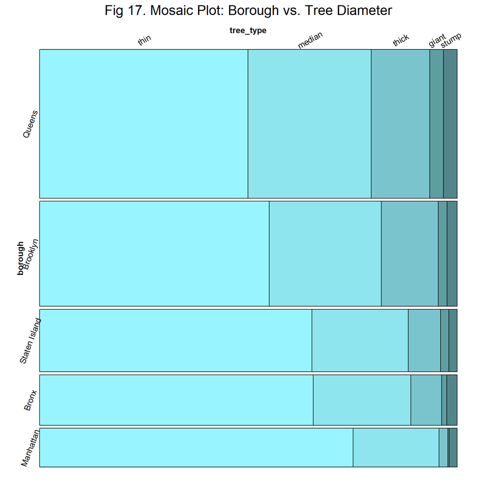

```r
Tree$borough <- factor(Tree$borough,
                      levels = c("Queens", "Brooklyn","Staten Island","Bronx","Manhattan"))
fillcolors=c("cadetblue1","cadetblue2","cadetblue3","cadetblue","cadetblue4")
mosaic(tree_type ~ borough, Tree,rot_labels = c(30, 0, 0, 70),gp=gpar(fill=fillcolors),
       main="Fig 17. Mosaic Plot: Borough vs. Tree Diameter")
```

### 4.4.3 Speceis vs. Borough

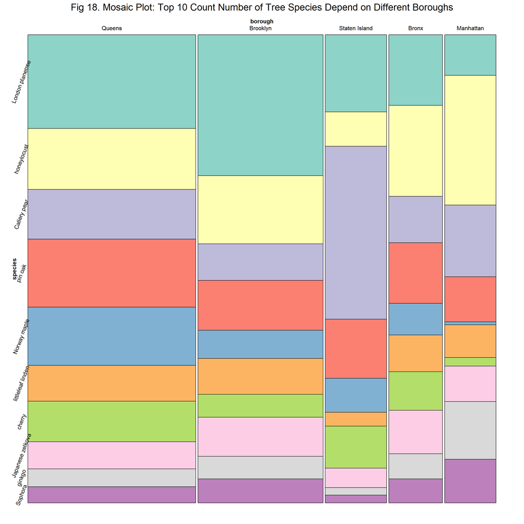

```r
library(RColorBrewer)
fillcolors <- brewer.pal(10, "Set3")
orderlevel = c("Queens","Brooklyn","Staten Island","Bronx","Manhattan")
orderlevel1 = c("London planetree", "honeylocust","Callery pear",
                "pin oak","Norway maple",
                "littleleaf linden","cherry",
                "Japanese zelkova","ginkgo","Sophora")
trees$borough = factor(trees$borough, levels = orderlevel)
trees$species = factor(trees$species , levels = orderlevel1)
vcd::mosaic(species ~ borough, trees,
            direction = c("v", "h"),
            rot_labels=c(0,0,0,70),
            gp = gpar(fill = fillcolors),
main = "Fig 18. Mosaic Plot: Top 10 Count Number of Tree Species Depend on Different Boroughs")
```

We can see top ten count numbers of tree species’ distribution depend on boroughs.

1)Top ten count numbers of tree species’ distribution on Brooklyn and Queens are very similar. We consider the reason of this is that both two boroughs is living areas, so the damage rate from human to trees are very similar.

2)Top ten count numbers of tree species’ distribution on Bronx and Manhattan are very similar. We consider the reason of this is that both two boroughs are very close, so the soil condition might be very similar .

3)Top ten count numbers of tree species’ distribution on Staten Island is so different from other boroughs, the reason of this might be the island is isolated place, the damage rate from hunnam, soil condition and other conditions might be different from other boroughs.

### 4.4.4 Health vs. User Type

```r
summary(Tree$user_type)
```

```
##  NYC Parks Staff TreesCount Staff        Volunteer
##           169986           296284           217518
```

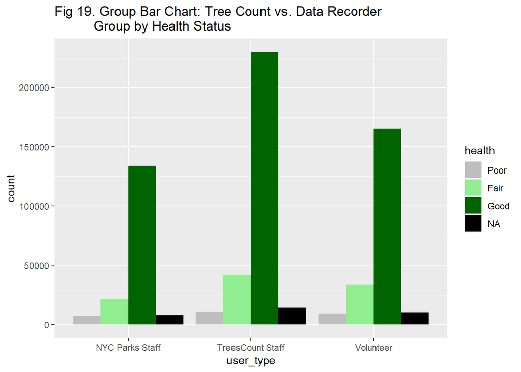

```r
healthcolors <- c("gray", "lightgreen", "darkgreen")
ggplot(Tree, aes(x = user_type, fill = health)) +
  geom_bar(position = "dodge") +
  scale_fill_manual(values = healthcolors, na.value = "black") +
  ggtitle("Fig 19. Group Bar Chart: Tree Count vs. Data Recorder
          Group by Health Status") + theme_gray()
```

Figure 19 indicates the tree’s health condition is not definitely related by the type of data recorders. Although the trees count staff do collect more good condition trees, it maybe because that trees count staff are assign more good condition trees to count.

### 4.4.5 Health vs. Borough

```r
summary(Tree$borough)
```

```
##        Queens      Brooklyn Staten Island         Bronx     Manhattan
##        250551        177293        105318         85203         65423
```

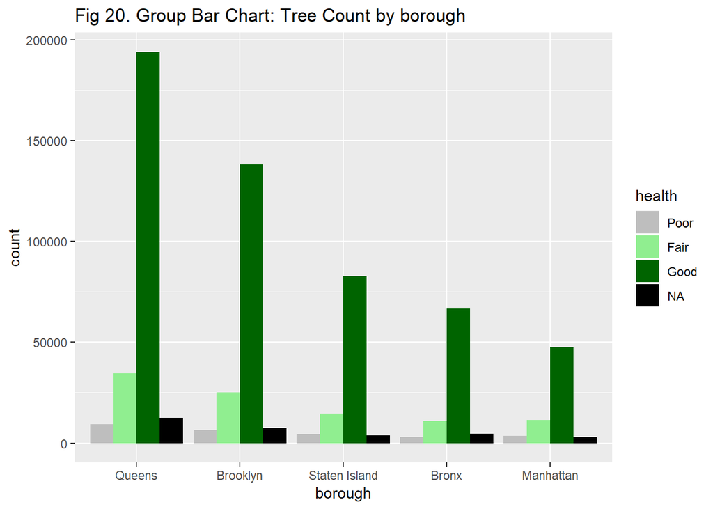

```r
healthcolors <- c("gray", "lightgreen", "darkgreen")
ggplot(Tree, aes(x = borough, fill = health)) +
  geom_bar(position = "dodge") +
  scale_fill_manual(values = healthcolors, na.value = "black") +
  ggtitle("Fig 20. Group Bar Chart: Tree Count by borough") + theme_gray()
```

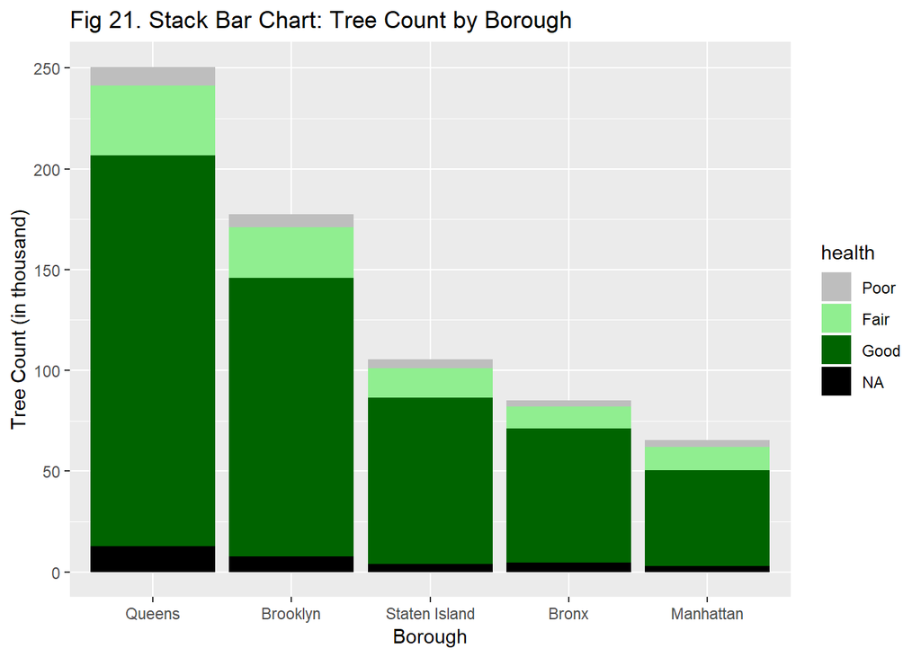

```r
HealthBorough<-ggplot(Tree, aes(x = borough, fill = health)) +
    geom_bar()+ scale_fill_manual(values = healthcolors,
                                  na.value = "black")+scale_y_continuous(labels=
                                                                      c("0","50","100","150","200","250"))+labs(x="Borough",
                                                                                                                y="Tree Count (in thousand)")
HealthBorough+ggtitle("Fig 21. Stack Bar Chart: Tree Count by Borough")
```

### 4.4.6 Health vs. Steward

```r
summary(Tree$steward)
```

```
##            1or2    3or4 4orMore    None    NA's
##       0  143557   19183    1610  487823   31615
```

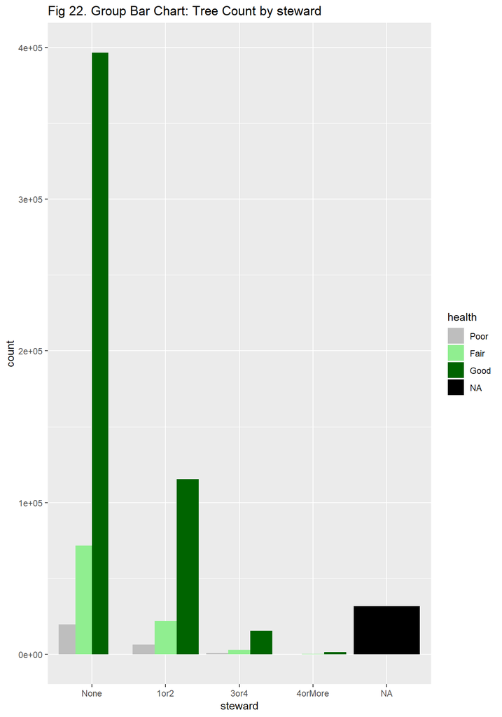

```r
Tree$steward <- factor(Tree$steward, ordered = TRUE,
                       levels <- c("None", "1or2", "3or4", "4orMore"))

healthcolors <- c("gray", "lightgreen", "darkgreen")
ggplot(Tree, aes(x = steward, fill = health)) +
  geom_bar(position = "dodge") +
  scale_fill_manual(values = healthcolors, na.value = "black") +
  ggtitle("Fig 22. Group Bar Chart: Tree Count by steward") + theme_gray()
```

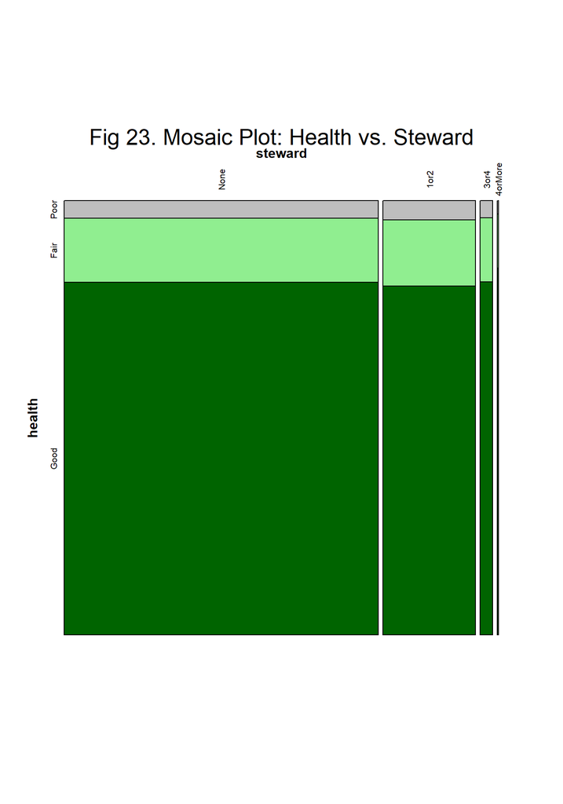

```r
library(grid)
vcd::mosaic(health~steward, Tree,
            direction = c("v", "h"), # <- order: steward ("v"), health ("h")
            gp = gpar(fill = healthcolors),
            rot_labels=c(90,0,0,90),offset_labels=c(1,0,0,0),
            labeling_args=list(gp_labels=gpar(fontsize=8)),
            main="Fig 23. Mosaic Plot: Health vs. Steward")
```

### 4.4.7 Status(Alive Percantage) vs. Borough

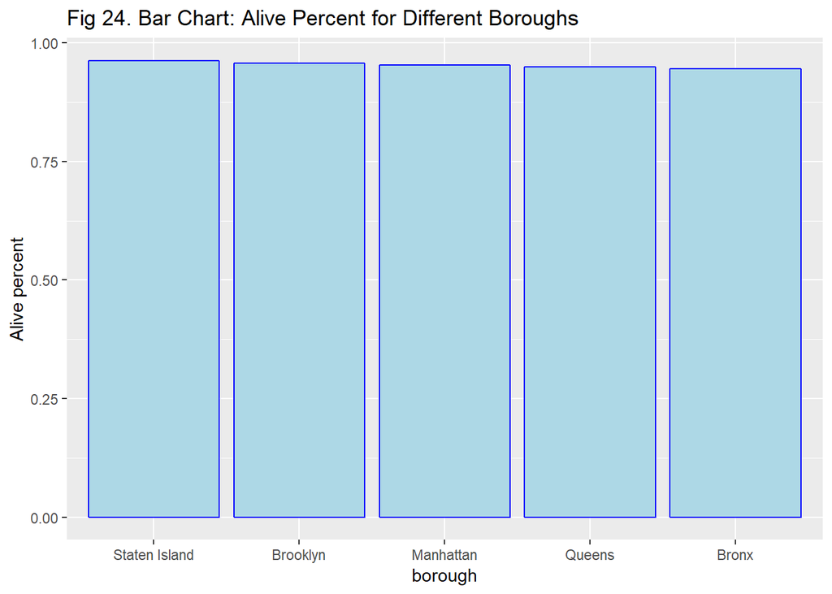

```r
borough_percent<-Tree%>%group_by(borough)%>%
summarize(total = n(),alive_tree_borough = sum(status=='Alive'))%>%
mutate(alive_percent_borough = alive_tree_borough/total)
borough_percent$borough <- factor(borough_percent$borough, levels = borough_percent$borough[order(-borough_percent$alive_percent_borough)])
borough_plot_alive<-ggplot(borough_percent,aes(x = borough,
                                               y = alive_percent_borough))+
geom_bar(stat = "identity",fill="lightblue", color="blue")+
ylab("Alive percent")+
ggtitle("Fig 24. Bar Chart: Alive Percent for Different Boroughs")
borough_plot_alive
```

Alive percent is transformed from status variable, alive percent = number of alive tree/number of total alive/dead/stump trees.

### 4.4.8 Status(Alive Percantage) vs. Species

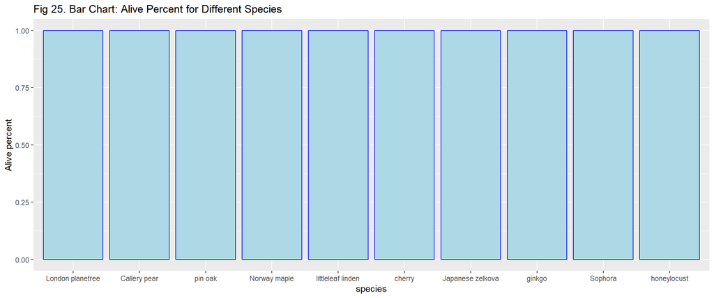

```r
species_percent<-trees%>%group_by(species)%>%
summarize(total = n(),alive_species = sum(status=='Alive'))%>%
mutate(alive_percent_species = alive_species/total)
species_percent$species <- factor(species_percent$species, levels = species_percent$species[order(-species_percent$alive_percent_species)])
species_plot_alive<-ggplot(species_percent,aes(x = species,
                                               y = alive_percent_species))+
geom_bar(stat = "identity",fill="lightblue", color="blue")+
ylab("Alive percent")+
ggtitle("Fig 25. Bar Chart: Alive Percent for Different Species")
species_plot_alive
```

From above two bar chart, we see status (alive percent) not depends on boroughs and top 10 tree species.

# 5. EXECUTIVE SUMMARY

We employe the data of 2015 trees census in NYC from the New York Open Data resource. The analysis of street trees census could help urban planner review the landscape of the city, figure out where to improve the nature of the city and contribute to the human living senario. Our project mainly investigate the situation of trees’ own properties (such as the survival rate, diameter, species distribution, etc.) and the attributes related to these properties (such as steward, guard, data recorder (user types), location (borough), local population, land area in NYC, etc.).

Following the data cleaning process mentioned in the Data Analysis Quality part, the distribution of tree’s own properties, including **status**, **health**, **tree species**, and **diameter**, are presented in histograms, bar charts, or tables. The dependencies of species and health against diameters are also examined. Additionally, the dependencies of their properties on the attributes were visualized, specifically on **borough**, **user type** (data recorder), and **steward**.

Below are takeaways we obtained from the main analysis part of data visualization in section 4.

- **Tree’s own properties:** there are around 95% of trees classified as in alive condition whereas the rest 5% specified into the dead and stump status, which consists of most NA features in this dataset. Within the alive trees, the trees in good condition is about 81.1%, fair condition is about 14.8% and poor condition is about 4.1%. The tree DBH (diameter at breast height) is centering at 5-6 with more than 100 species.
- **Tree’s property dependencies:** consistent with the common sense, the thicker the trees, the better the health conditions they may be in. Besides, the diameter of a tree highly depends on its species.
- **Tree’s property attributes:** a tree’s location (in which borough) is always discussed as a popular consideration. Firstly, the map of trees count by boroughs is plotted below, where Staten Island owns the highest greening proportion while Manhattan hits the lowest level.

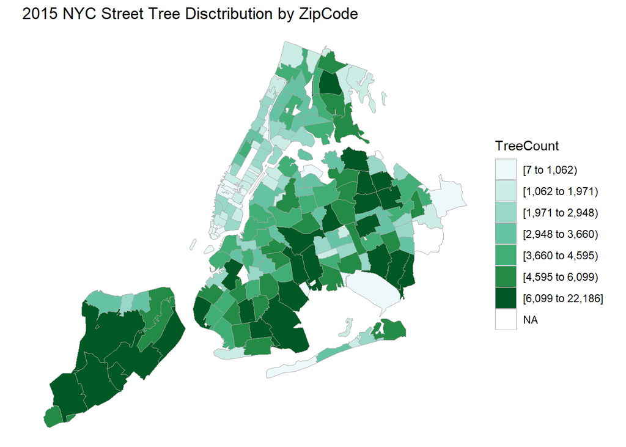

```r
choro$title="2015 NYC Street Tree Disctribution by ZipCode"
choro$render()
```

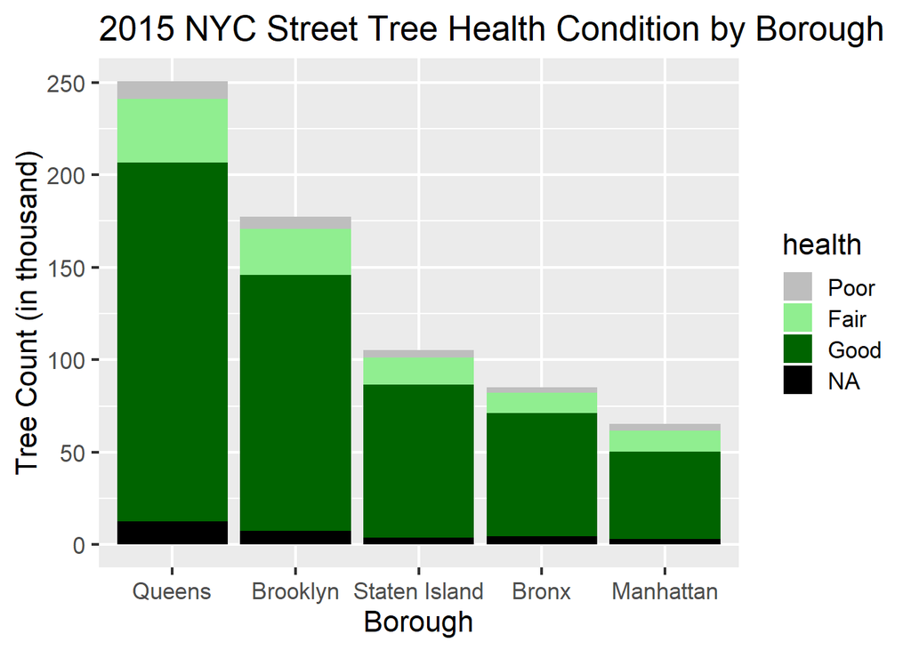

```r
HealthBorough+theme_grey(16)+
  ggtitle("2015 NYC Street Tree Health Condition by Borough")
```

Thirdly, the relationship between diameters and boroughs is shown below. Queens area has the largest median of tree diameters. Queens and Brooklyn have a wider range of diameter than other boroughs. Bronx and Manhattan have the smallest diameters, which may be caused by the more advanced level of urbanization in these two boroughs.

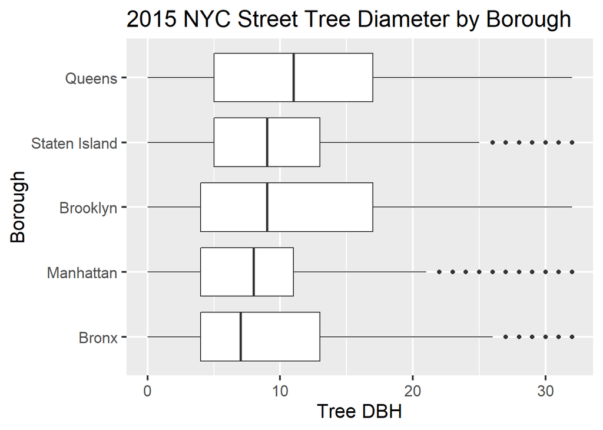

```r
BoroughDia+theme_grey(16)+ggtitle("2015 NYC Street Tree Diameter by Borough")
```

Lastly, the tree species distribution in boroughs are plotted. According to the result, the urbanizations and soil conditions are considered into every borough’s greening plan. We refill this plot via the color blind brewer as below:

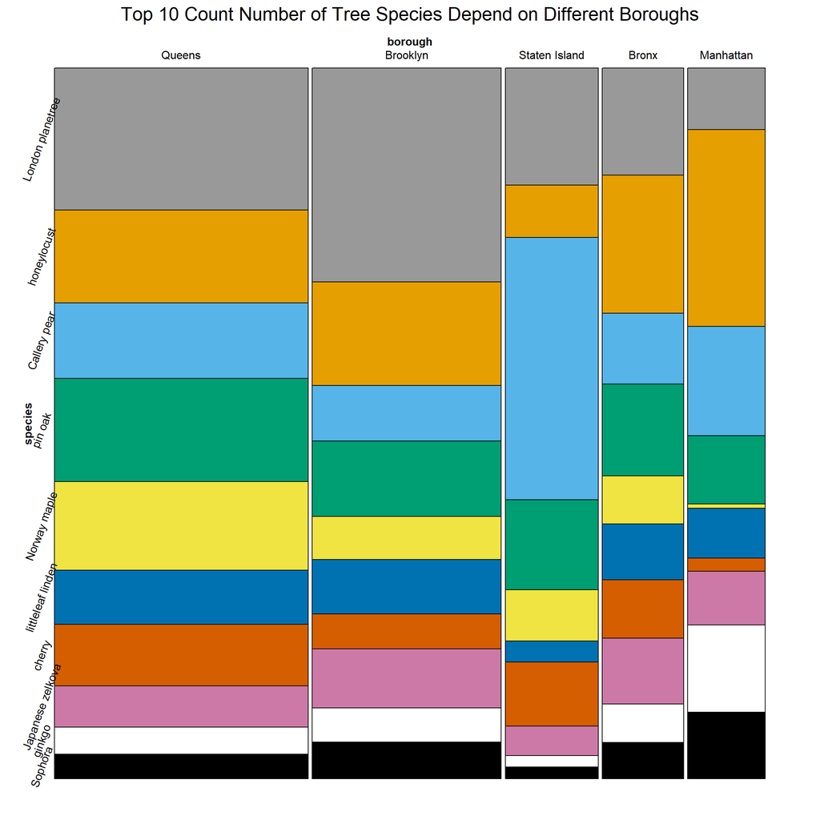

```r
fillcolors <- c("#999999", "#E69F00", "#56B4E9", "#009E73",
                "#F0E442", "#0072B2", "#D55E00", "#CC79A7","white","#000000")

orderlevel2 = c("Queens","Brooklyn","Staten Island","Bronx","Manhattan")
orderlevel3 = c("London planetree", "honeylocust","Callery pear",
                "pin oak","Norway maple","littleleaf linden","cherry","Japanese zelkova","ginkgo","Sophora")
trees$borough = factor(trees$borough, levels = orderlevel2)
trees$species = factor(trees$species , levels = orderlevel3)
mosaic_final<-vcd::mosaic(species ~ borough, trees,
            direction = c("v", "h"),
            rot_labels=c(0,0,0,70),
            gp = gpar(fill = fillcolors),
main = "Top 10 Count Number of Tree Species Depend on Different Boroughs")
```

# 6. INTERACTIVE COMPONENT

Our group developed a interactive app by Shiny named “Explore Trees in NYC”, including two parts: “Tree Species Distribution” and “Related Variables to Borough”. It is published on the web at https://edvtreeanalysis.shinyapps.io/application/. The code link is https://github.com/RuizhiZhang/EDAVfinalprojectNYCtrees/tree/master/Shiny%20app

*Remark: Because the dataset is big, the time to open it may be a little longer than usual. Thanks for being patient!*

In the Data Analysis part, we found that there are hunderds of different species of street trees spreaded in NYC, with the greatest of 87014 tree counts in “London planetree”, and the smallest of 183 tree counts in “Amur cork tree”. It’s interesting to see such a wide variety of trees and a large difference in the total amount of each tree species, so we give a further exploration on the spatial distribution of tree species. Interactive spatial map is considered to be a wonderful way to demonstrate this information conveniently. “Borough” is a crucial variable in our analysis that other variables relate with and our conclusions vary correspondingly to it, therefore, it is helpful to show the mosaic plots by boroughs and let these variables interact accordingly to the users’ choices.

The objective of interactive component is to show: a) the spatial distribution of tree species on a map; and b) the relationship between “borough” and its related variables. In order to implement the app with a concise and user-friendly design, we choose “Shiny” as the development tool and deploy it on shinyapps.io. Aline with the two design objects, the app mainly included two following parts respectively.

1)Trees Species Spatial Distribution Part

The distributions of top 10 tree species vary from borough to borough. Our interactive app is able to show our audience the distribution of tree species upon their interests. The audience will see a map of five boroughs of NYC. Aach green circle represents a single tree with corresponding location on the NYC map. For interaction, audiences can choose a single specie from the pull-down list we provide, and then the distribution of that chosen tree species will be ploted on the map accordingly. A checkbox named “Alive” will only return the chosen species trees in alive status.(Note: Only one species can be chosen at each time.)

2)Related Variables to Borough Part

The two borough related variables, “user_type”(shown as “Recorder_type”) and “species”(shown as “Tree_species”), are chosen in this part. We found that the proportion of “user_type”(recorder types) is different in each borough from the previous data quality analysis. This might cause the occurrence of bianess in the dataset, as different recorder groups may have different knowledge and preferences when recording the data. Therefore, in this part, we create the interaction play to aware our audience to the data recording bias. Besides, the relationship between species and borough is another interesting point that audiences would like to know.

Audiences can select any interested variable to start the interaction. After picking a variable, a mosaic plot between that specific variable and boroughs will be demonstrated. This interactivity design can help the user observe the relationship between their interested variables and boroughs clearly.

During the development of the “Explore Trees in NYC” app, the main constraint is the slow speed of execution, which is as a result of the large scale of the dataset. With 683,788 observations and 45 variables in the dataset, the processing time is much longer than we expected. To speed up this interaction process, only the top largest 10 tree species options are provided in the pull-down selection bar. In the future, we would like to focus on improving the responsing time in the “Trees Species Spatial Distribution Part” and provide a better interaction experience to the app users.

# 7. CONCLUSIONS AND LIMITATIONS

New York City is one of biggest green city in the world. It has hundreds of tree species and great tree planting survival rate as high as 95%. Within the alive trees, the trees in good health condition is about 81.1%. Some hard-to-survival trees need more steward to keep them alive, but the impaction of number of steward on health is limited.

Consistent with the common sense, our analysis shows that the thicker trees have the better health conditions. However, the diameter of a tree highly depends on its species too. The tree DBH (diameter at breast height) is centering at 5-6 with more than 100 species.

Our project analysis has following Limitations:

First, we do not include all the hundreds of species in our tree analysis. The complete inclusion of species will make the mosaic figure be too complicated and thus more difficult for readers to see a clear relationship from it. The top 10 largest number of species are picked into the interactive analysis as a good and moderate representative subset of the whole dataset, since the total amount of top 10 accounts for more than 50% of all alive trees already.

Second, people who lacks enough experience and knowledge may cause bias in collecting the tree data. From the 2015 Street Tree Census, the âuser_typeâ variable which shows who records the tree data includes three types of data collectors: NYC Park staff, Trees Count staff and Volunteer. The volunteers who usually only be trained a couple of hours before the collecting data job may make more measurement errors during their collecting work.

Third, the problems that influence a treeâs status or health such as stones, grate, trunk wire are not further discussed in our analysis because of the data availability and complexity.

Forth, the data availability of only 2015 Street Tree Census not all recent years, constrains our probability to provide a further dynamic greening level analysis in New York City along the course of time .